# R Notebook

### Share phase

#### Analyzing data using visualization with ggplot2

##### Ploltting Average Trip Duration by User Type & Number of Users by User Type

The first plot shows that average trip duration for **customer** are **higher** than the **subscriber**. However, in the second plot, the number of **subscribers** that uses the bike are much **more** than the **customers**.

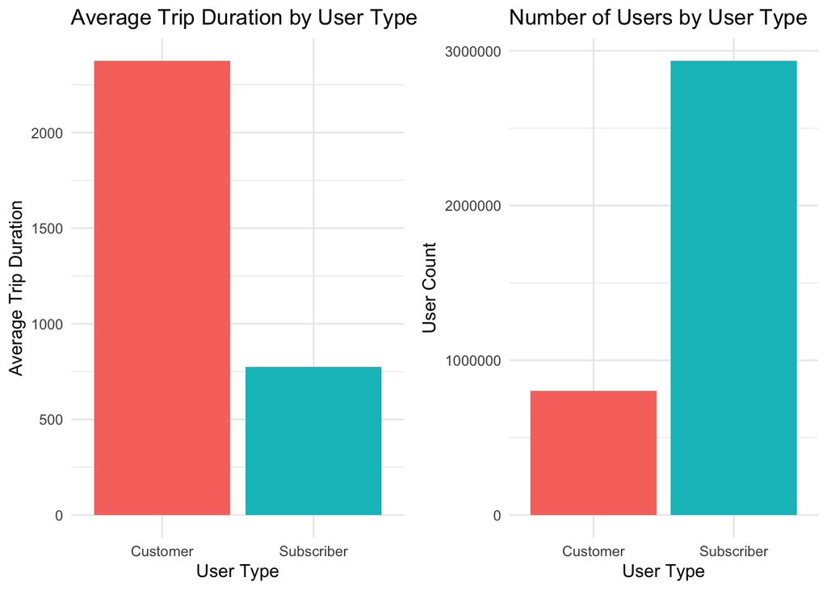

##### Plotting Average Trip Duration by Day of Week & Weekly Bike Usage

The first plot indicates that the average trip duration for **weekdays** are **lower** than **weekends**. In the second plot, the number of bike usage is significantly **higher** in **weekdays** compare to **weekends**.

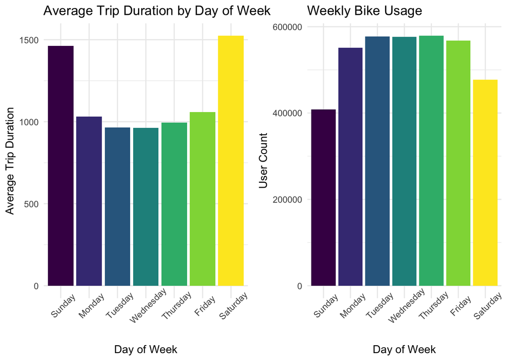